# GH1044372_AI_Applications

**Personal information**

1. Name:- Om Dipak Patil
2. GH Number:- GH1044372
3. M504C AI and Application

**Product Performance and Inventory Data Analysis**

**Business Context:-** As one of the biggest e-commerce platforms in the world, amazon generates enoromous amounts of sales and consumer data every day . This project transforms raw traditional data into useful insights that can inform business strategies. The primary objective to study sales performances, revenue contribution, and customer distribution from both the domestic and international sides of the market. The dataset was prepared for further analysis by performing data cleaning, treatment of missing values, and some data preprocessing. Subsequently, these data were used to build several visualizations and dashboard, suchh as high-performing-customers, revenue contributions by region, sales distribution, and business metrics relationship. Thess insights shed light on product demand patterns, customer purchasing behaviors, and revenue drivers.

The finding serve as a solid basis for advancing inventory planning, customer targeting, supply pricing, and resources allocation optimization. Therefore, in the governing conditions of e-commerce, turning complex data into actionable information faciliates effective decision-making toward sustainable growth.

**Introduction:-** In today's competitive world of e-commerce, companies such as Amazon adopt data driven methodologies to ensure efficiency and maximize profitability. Each order placed gives information related to customers, products, sales channels, and geographical areas. Yet data, when raw, possesses inconsistencies, missing values, and noise, further making it difficult to arrive at meaningful conclusions without rigt processing.

This become bottleneck that the project aims to address in analyzing Amazon's selling data. Data preprocessing is carried out by cleaning the data, addressing missing values, dropping inappropriate fields, and aggregating sales performance along various parameters to map unstructured raw data into structured data to be analyzed later. The analysis goes on to explore important factors like top customers, sales distribution between domestic and international market, revenue trends based on geography, and correlation between various sales parameters. An easy-to-use visual dashboard and chart display interpretations of result, providing support for decisions concerning marketing, inventory, and customer strategy.

**Objectives:**

The Primary goal of the project is to strengthen Data-Driven Decision-Making in inventory optimization and product management by carefully analyzing inventory records and product perfromance. The study is designed to achive the following objectives:

1. **Assess Product Performance**
2. **Enhance inventory Control**
3. **Evaluate Profitability**
4. **Support Strategic Decision- Making**

**Data Scources:-** The dataset is from the public source of kaggle.com and the link to datasource is:- Dataset :- https://www.kaggle.com/code/youssefelbadry10/e-commerce-sales-eda/input

**How this notebook is organized based on assesment criteria?** This notebook is arranged logically to cover each assessment criterion in detail. To present a concise, data-driven examination of inventory management and product performance, each component builds upon the one before it.

**Business Questions:-**

1. What are the most profitable products and categories, and how can we use this to improve stock and sales management?
2. How can we use distribution of order amounts and daily sales patterns to improve marketing, inventory, and operational planning?
3. Which products are favored in abroad, and how do sales abroad change from month to month and day to day? How can these insights guide international inventory, marketing, and operational approches?
4. Which Nations, localities, and foreign consumers make up the largest portion of Amazon's revenue, and what effect does the ratio of domestic to foreign revenue have on company's overall business plan?
5. How can identify these connections aid in developing more intelligent pricing schemes, product, and inventory plans that increase overall profits? Which sales and performance metrics typically move together?
6. In which international markets do revenue and sales volume peak, and how can Amazon leverage this information to enhance its global operations, inventory control, and marketing tactis?

**Importing all the libraries required for this Analysis Report.**

```python
import pandas as pd # Pandas is the strong foundation of Python's Data Analysis
# It utilize CSV, Excel, SQL and other datasets, it carry out aggregation, combinig, grouping, and filtering.
import numpy as np # NumPy offers array operations and quick numerical compulations, Effectively manage mathematical computations.
# for example:- It used for instance, figuring out inventory turnover ratios.
import matplotlib as mpl #The core Python charting library is called Matplotlib
# Plots can have their typefaces, colors, figure sizes, and style changed.
import matplotlib.pyplot as plt # Pyplot offers a graphical creation interface to MATLAB
# It used to create charts (scatter, pie, bar, line, etc), It include titles, legends, and labels.
%matplotlib inline
import seaborn as sns # Seaborn offers a high-level interface for producing visually appealing and educational visualizations.
# It is based on matplotlib, it use fewer lines of code to create complex charts.
# For emaple:- it include statistical context by using distribution plots, box, and heatmaps.
import warnings
warnings.filterwarnings('ignore')
```

```python
# Open the drive and load the dataset from a specified directory.
# Show the first five rows.
df = pd.read_csv("/content/drive/MyDrive/Colab Notebooks/Amazon Sale Report.csv")
print("Preview of the dataset")
df.head()
```

```
Preview of the dataset
```

|  | index | Order ID | Date | Status | Fulfilment | Sales Channel | ship-service-level | Style | SKU | Category | ... | currency | Amount | ship-city | ship-state | ship-postal-code | ship-country | promotion-ids | B2B | fulfilled-by | Unnamed: 22 |
| --- | --- | --- | --- | --- | --- | --- | --- | --- | --- | --- | --- | --- | --- | --- | --- | --- | --- | --- | --- | --- | --- |
| 0 | 0 | 405-8078784-5731545 | 04-30-22 | Cancelled | Merchant | Amazon.in | Standard | SET389 | SET389-KR-NP-S | Set | ... | INR | 647.62 | MUMBAI | MAHARASHTRA | 400081.0 | IN | NaN | False | Easy Ship | NaN |
| 1 | 1 | 171-9198151-1101146 | 04-30-22 | Shipped - Delivered to Buyer | Merchant | Amazon.in | Standard | JNE3781 | JNE3781-KR-XXXL | kurta | ... | INR | 406.00 | BENGALURU | KARNATAKA | 560085.0 | IN | Amazon PLCC Free-Financing Universal Merchant ... | False | Easy Ship | NaN |
| 2 | 2 | 404-0687676-7273146 | 04-30-22 | Shipped | Amazon | Amazon.in | Expedited | JNE3371 | JNE3371-KR-XL | kurta | ... | INR | 329.00 | NAVI MUMBAI | MAHARASHTRA | 410210.0 | IN | IN Core Free Shipping 2015/04/08 23-48-5-108 | True | NaN | NaN |
| 3 | 3 | 403-9615377-8133951 | 04-30-22 | Cancelled | Merchant | Amazon.in | Standard | J0341 | J0341-DR-L | Western Dress | ... | INR | 753.33 | PUDUCHERRY | PUDUCHERRY | 605008.0 | IN | NaN | False | Easy Ship | NaN |
| 4 | 4 | 407-1069790-7240320 | 04-30-22 | Shipped | Amazon | Amazon.in | Expedited | JNE3671 | JNE3671-TU-XXXL | Top | ... | INR | 574.00 | CHENNAI | TAMIL NADU | 600073.0 | IN | NaN | False | NaN | NaN |

5 rows × 24 columns

```python
print("Basic Inforamtion about the dataset")
df.info() # This function is a pandas function it is used to show the information of dataset.
# It describe the name of columns and their types.
```

```
Basic Inforamtion about the dataset
<class 'pandas.core.frame.DataFrame'>
RangeIndex: 128975 entries, 0 to 128974
Data columns (total 24 columns):
 #   Column              Non-Null Count   Dtype
---  ------              --------------   -----
 0   index               128975 non-null  int64
 1   Order ID            128975 non-null  object
 2   Date                128975 non-null  object
 3   Status              128975 non-null  object
 4   Fulfilment          128975 non-null  object
 5   Sales Channel       128975 non-null  object
 6   ship-service-level  128975 non-null  object
 7   Style               128975 non-null  object
 8   SKU                 128975 non-null  object
```

[output cut: 17 more lines]

Numerical columns: The df.describe() briefly introduces distribution and variance to numerical columns with count, mean standard deviation, min max, and quartiles.

```python
print("Statistics for Numeric Columns") # It shows the statistics for all numeric columns that are present in the Dataset.
print(df.describe())
```

```
Statistics for Numeric Columns
               index            Qty         Amount  ship-postal-code
count  128975.000000  128975.000000  121180.000000     128942.000000
mean    64487.000000       0.904431     648.561465     463966.236509
std     37232.019822       0.313354     281.211687     191476.764941
min         0.000000       0.000000       0.000000     110001.000000
25%     32243.500000       1.000000     449.000000     382421.000000
50%     64487.000000       1.000000     605.000000     500033.000000
75%     96730.500000       1.000000     788.000000     600024.000000
max    128974.000000      15.000000    5584.000000     989898.000000
```

Categorical columns: To provide better comprehend categorical distributions, display the count, number of unique values, most frequent category, and its frequency.

```python
print("Statistics for Categorical Columns")  # It shows the statistics for all categorical columns (object) that are present in the Dataset.
print(df.describe(include=['object']))
```

```
Statistics for Categorical Columns
                   Order ID      Date   Status Fulfilment Sales Channel   \
count                128975    128975   128975     128975         128975
unique               120378        91       13          2              2
top     403-4984515-8861958  05-03-22  Shipped     Amazon      Amazon.in
freq                     12      2085    77804      89698         128851

       ship-service-level    Style           SKU Category    Size        ASIN  \
count              128975   128975        128975   128975  128975      128975
unique                  2     1377          7195        9      11        7190
top             Expedited  JNE3797  JNE3797-KR-L      Set       M  B09SDXFFQ1
freq                88615     4224           773    50284   22711         773

       Courier Status currency  ship-city   ship-state ship-country  \
count          122103   121180     128942       128942       128942
unique              3        1       8955           69            1
top           Shipped      INR  BENGALURU  MAHARASHTRA           IN
freq           109487   121180      11217        22260       128942

                                       promotion-ids fulfilled-by Unnamed: 22
count                                          79822        39277       79925
unique                                          5787            1           1
top     IN Core Free Shipping 2015/04/08 23-48-5-108    Easy Ship       False
freq                                           46100        39277       79925
```

**Check the missing values in each column**

```python
print("Display the missing values in each column of our Dataset")
print(df.isnull().sum())
```

```
Display the missing values in each column of our Dataset
index                     0
Order ID                  0
Date                      0
Status                    0
Fulfilment                0
Sales Channel             0
ship-service-level        0
Style                     0
SKU                       0
Category                  0
Size                      0
ASIN                      0
Courier Status         6872
Qty                       0
currency               7795
Amount                 7795
ship-city                33
ship-state               33
ship-postal-code         33
ship-country             33
promotion-ids         49153
B2B                       0
fulfilled-by          89698
Unnamed: 22           49050
dtype: int64
```

To know the degree of incompleteness of data, the dataset was analyzd first for any missing values. The analysis gave total number of missing values, which shall be addressed as follows: In categorical columns, the mode (most frequently occuring value) shall be imputed, while the median shall be imputed in numerical columns, and columns if not relevant to the analysis shall be droped.

```python
# Fill the missing values by calculating mode for categorical columns.
# Then Fill the missing values  by calculating median for numerical value.
df['Courier Status'] = df['Courier Status'].fillna(df['Courier Status'].mode()[0])
df['currency'] = df['currency'].fillna(df['currency'].mode()[0])
df['ship-city'] = df['ship-city'].fillna(df['ship-city'].mode()[0])
df['ship-state'] = df['ship-state'].fillna(df['ship-state'].mode()[0])
df['ship-postal-code'] = df['ship-postal-code'].fillna(df['ship-postal-code'].mode()[0])
df['ship-country'] = df['ship-country'].fillna(df['ship-country'].mode()[0])
df['Amount'] = df['Amount'].fillna(df['Amount'].median())
# By using drop function we can drop unnecessary columns or irrelevant data from the dataset that are not usefull for our Analysis
df.drop(columns=['promotion-ids', 'fulfilled-by', 'Unnamed: 22'], inplace=True)
# Finally after filling with mode, median and using drop function verify that in our dataset all missing values has been calculated.
print("Missing Values After Filling")
print(df.isnull().sum())
```

```
Missing Values After Filling
index                 0
Order ID              0
Date                  0
Status                0
Fulfilment            0
Sales Channel         0
ship-service-level    0
Style                 0
SKU                   0
Category              0
Size                  0
ASIN                  0
Courier Status        0
Qty                   0
currency              0
Amount                0
ship-city             0
ship-state            0
ship-postal-code      0
ship-country          0
B2B                   0
dtype: int64
```

```python
# A Dataframe's shape attribute helps us understand the size of the dataset by identifying how many rows (records) and columns it contains.
df.shape
```

```
(128975, 21)
```

To find the duplicate rows in our dataset we will use this approch.

```python
duplicates = df[df.duplicated()] # This function is used to find the duplicate rows in our dataset.
print("Duplicate Rows:")
print(duplicates)
print(f"\nTotal duplicate rows: {duplicates.shape[0]}")
```

```
Duplicate Rows:
Empty DataFrame
Columns: [index, Order ID, Date, Status, Fulfilment, Sales Channel , ship-service-level, Style, SKU, Category, Size, ASIN, Courier Status, Qty, currency, Amount, ship-city, ship-state, ship-postal-code, ship-country, B2B]
Index: []

[0 rows x 21 columns]

Total duplicate rows: 0
```

**From the above analysis:**

After resloving the missing values, an insight that can be drawn from it is that there are no missing values in the data. there are fixed number of numerical and categorical columns in the dataset, each filled in with median (for numeric data) or mode (for categorical data).

**The dataset, therefore is clean and ready for further analysis: No duplicate exist**

**How many features are there in the datset, and how many of them are categorical versus numerical?**

```python
total_features = df.shape[1] # Create the total number of features (columns) in dataset
numerical_cols = df.select_dtypes(include=['int64', 'float64']).columns
num_numerical = len(numerical_cols) # Calculate the length of numerical columns
categorical_cols = df.select_dtypes(include=['object']).columns # Create the total number of categorical columns.
num_categorical = len(categorical_cols) # Calculate the length of categorical columns.
# Overview of results
print(f"Total features we have in our dataframe: {total_features}")
print(f"Numerical columns: {num_numerical} -> {list(numerical_cols)}")
print(f"Categorical columns: {num_categorical} -> {list(categorical_cols)}")
```

```
Total features we have in our dataframe: 21
Numerical columns: 4 -> ['index', 'Qty', 'Amount', 'ship-postal-code']
Categorical columns: 16 -> ['Order ID', 'Date', 'Status', 'Fulfilment', 'Sales Channel ', 'ship-service-level', 'Style', 'SKU', 'Category', 'Size', 'ASIN', 'Courier Status', 'currency', 'ship-city', 'ship-state', 'ship-country']
```

**Exploring Basic Metadata**

Basic metadata is investigated by stating all the distinct product categories, identifying the earliest and latest transaction dates, determining the min, max, and average product price. It gives a brief overview of price distribution in time and in dataset structure.

```python
# Show all unique categories in the datset
print("Unique Product Categories")
print(df['Category'].unique()) # List the distinct categories
print(f"Total unique categories: {df['Category'].nunique()}") # Calculate the total count of unique categories.
df['Date'] = pd.to_datetime(df['Date'], errors='coerce') # Confirm that the DATE column is in proper datetime formate for better and accurate time analysis.
print("\n Date Range") # Show's the Date range in the dataset.
print(f"Earliest date: {df['Date'].min()}")
print(f"Latest date: {df['Date'].max()}")
print("\n Price Range") # Display the price range in datset.
print(f"Minimum price: {df['Amount'].min()}") # Minimum Price
print(f"Maximum price: {df['Amount'].max()}")# maximum Price
print(f"Average price: {df['Amount'].mean():.2f}") # Calculate mean or average .
```

```
Unique Product Categories
['Set' 'kurta' 'Western Dress' 'Top' 'Ethnic Dress' 'Bottom' 'Saree'
 'Blouse' 'Dupatta']
Total unique categories: 9

 Date Range
Earliest date: 2022-03-31 00:00:00
Latest date: 2022-06-29 00:00:00

 Price Range
Minimum price: 0.0
Maximum price: 5584.0
Average price: 645.93
```

**Feature Engineering: Profit & Profit Margin (Proxy) :-** We construct the proxy features because the dataset only contains the amount column:

1. Profit_proxy -> Substitutes Amount for actual profit.
2. Profin_Margin_proxy -> Each row's % contribution to overall revenue.

```python
df["Profit_proxy"] = df["Amount"]
df["Profit_Margin_proxy"] = df["Amount"] / df["Amount"].sum() * 100
df.head()
```

|  | index | Order ID | Date | Status | Fulfilment | Sales Channel | ship-service-level | Style | SKU | Category | ... | Qty | currency | Amount | ship-city | ship-state | ship-postal-code | ship-country | B2B | Profit_proxy | Profit_Margin_proxy |
| --- | --- | --- | --- | --- | --- | --- | --- | --- | --- | --- | --- | --- | --- | --- | --- | --- | --- | --- | --- | --- | --- |
| 0 | 0 | 405-8078784-5731545 | 2022-04-30 | Cancelled | Merchant | Amazon.in | Standard | SET389 | SET389-KR-NP-S | Set | ... | 0 | INR | 647.62 | MUMBAI | MAHARASHTRA | 400081.0 | IN | False | 647.62 | 0.000777 |
| 1 | 1 | 171-9198151-1101146 | 2022-04-30 | Shipped - Delivered to Buyer | Merchant | Amazon.in | Standard | JNE3781 | JNE3781-KR-XXXL | kurta | ... | 1 | INR | 406.00 | BENGALURU | KARNATAKA | 560085.0 | IN | False | 406.00 | 0.000487 |
| 2 | 2 | 404-0687676-7273146 | 2022-04-30 | Shipped | Amazon | Amazon.in | Expedited | JNE3371 | JNE3371-KR-XL | kurta | ... | 1 | INR | 329.00 | NAVI MUMBAI | MAHARASHTRA | 410210.0 | IN | True | 329.00 | 0.000395 |
| 3 | 3 | 403-9615377-8133951 | 2022-04-30 | Cancelled | Merchant | Amazon.in | Standard | J0341 | J0341-DR-L | Western Dress | ... | 0 | INR | 753.33 | PUDUCHERRY | PUDUCHERRY | 605008.0 | IN | False | 753.33 | 0.000904 |
| 4 | 4 | 407-1069790-7240320 | 2022-04-30 | Shipped | Amazon | Amazon.in | Expedited | JNE3671 | JNE3671-TU-XXXL | Top | ... | 1 | INR | 574.00 | CHENNAI | TAMIL NADU | 600073.0 | IN | False | 574.00 | 0.000689 |

5 rows × 23 columns

**Feature Engineering: Sales Performance Metrics:-** This features record performance at the level of orders and product: Revenue_per_product tracks average revenue per order to distinguish between top and worst performance while total_Quantity_sold tracks total demand for product.

```python
df["Revenue_per_Product"] = df["Amount"] * df["Qty"] # It calculate total revenue per product in each order.
avg_sales = df.groupby("Order ID")["Revenue_per_Product"].mean().reset_index() # Find the average
avg_sales.rename(columns={"Revenue_per_Product": "Average_Sales_per_Order"}, inplace=True)
df = df.merge(avg_sales, on="Order ID", how="left")
total_qty = df.groupby("SKU")["Qty"].sum().reset_index() # Calculate total quantity sold for each SKU
total_qty.rename(columns={"Qty": "Total_Quantity_Sold"}, inplace=True)
df = df.merge(total_qty, on="SKU", how="left")
df.head()
```

|  | index | Order ID | Date | Status | Fulfilment | Sales Channel | ship-service-level | Style | SKU | Category | ... | ship-city | ship-state | ship-postal-code | ship-country | B2B | Profit_proxy | Profit_Margin_proxy | Revenue_per_Product | Average_Sales_per_Order | Total_Quantity_Sold |
| --- | --- | --- | --- | --- | --- | --- | --- | --- | --- | --- | --- | --- | --- | --- | --- | --- | --- | --- | --- | --- | --- |
| 0 | 0 | 405-8078784-5731545 | 2022-04-30 | Cancelled | Merchant | Amazon.in | Standard | SET389 | SET389-KR-NP-S | Set | ... | MUMBAI | MAHARASHTRA | 400081.0 | IN | False | 647.62 | 0.000777 | 0.0 | 0.0 | 29 |
| 1 | 1 | 171-9198151-1101146 | 2022-04-30 | Shipped - Delivered to Buyer | Merchant | Amazon.in | Standard | JNE3781 | JNE3781-KR-XXXL | kurta | ... | BENGALURU | KARNATAKA | 560085.0 | IN | False | 406.00 | 0.000487 | 406.0 | 406.0 | 100 |
| 2 | 2 | 404-0687676-7273146 | 2022-04-30 | Shipped | Amazon | Amazon.in | Expedited | JNE3371 | JNE3371-KR-XL | kurta | ... | NAVI MUMBAI | MAHARASHTRA | 410210.0 | IN | True | 329.00 | 0.000395 | 329.0 | 329.0 | 12 |
| 3 | 3 | 403-9615377-8133951 | 2022-04-30 | Cancelled | Merchant | Amazon.in | Standard | J0341 | J0341-DR-L | Western Dress | ... | PUDUCHERRY | PUDUCHERRY | 605008.0 | IN | False | 753.33 | 0.000904 | 0.0 | 0.0 | 257 |
| 4 | 4 | 407-1069790-7240320 | 2022-04-30 | Shipped | Amazon | Amazon.in | Expedited | JNE3671 | JNE3671-TU-XXXL | Top | ... | CHENNAI | TAMIL NADU | 600073.0 | IN | False | 574.00 | 0.000689 | 574.0 | 574.0 | 16 |

5 rows × 26 columns

**Business Question 1:- What are the most profitable products and categories, and how can we use this to improve stock and sales management?**

**Solution:-** We examined the dataset at the product and category levels in order to answer the question. The product with biggest sales are highlighted in the bar chart of the top 10 products by revenueon the left, which also shows which SKUs should have priority for inventory and possible promotions. The other chart on right displays total revenue by product category, highlighting the categories that make up the majority of the company's total revenue.

By combining these data, the business can concentrate on high-performing goods and categories, manage inventory efficiently, and create targeted marketing strategies to boost sales and improve inventory control overall

```python
## Aggregate sales metrics per product (SKU)
sales_summary = df.groupby("SKU").agg({
    "Revenue_per_Product": "sum",
    "Average_Sales_per_Order": "mean",
    "Total_Quantity_Sold": "max"
}).reset_index()
# Rename columns for clarity
sales_summary.rename(columns={
    "Revenue_per_Product": "Total_Revenue",
    "Average_Sales_per_Order": "Avg_Sales_per_Order",
    "Total_Quantity_Sold": "Total_Quantity"
}, inplace=True)
# Arrange the products by highest total revenue.
sales_summary = sales_summary.sort_values(by="Total_Revenue", ascending=False)
```

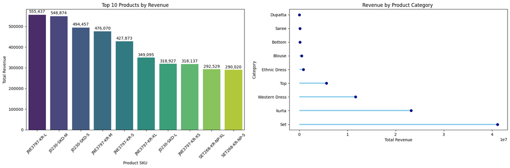

```python
product_revenue = df.groupby('SKU')['Amount'].sum().sort_values(ascending=False).head(10) # Display top 10 product by revenue
category_revenue = df.groupby('Category')['Amount'].sum().sort_values(ascending=False) # Shows revenue per category.

fig, axes = plt.subplots(1, 2, figsize=(18,6))
# This bar chart shows the top 10 products by revenue
sns.barplot(
    x=product_revenue.index,
    y=product_revenue.values,
    palette="viridis",
    ax=axes[0]
)
axes[0].set_title("Top 10 Products by Revenue")
axes[0].set_xlabel("Product SKU")
axes[0].set_ylabel("Total Revenue")
axes[0].tick_params(axis='x', rotation=45)
for i, v in enumerate(product_revenue.values):
    axes[0].text(i, v + 0.01*v, f"{v:,.0f}", ha='center', va='bottom')
    # This cahrt illustrate the revenue by category of product
axes[1].hlines(
    y=category_revenue.index,
    xmin=0,
    xmax=category_revenue.values,
    color='skyblue', linewidth=3
)
axes[1].plot(category_revenue.values, category_revenue.index, "o", color='navy')
axes[1].set_title("Revenue by Product Category ")
axes[1].set_xlabel("Total Revenue")
axes[1].set_ylabel("Category")

plt.tight_layout()
plt.show()
```

**Business Question 2:- How can we use distribution of order amounts and daily sales patterns to improve marketing, inventory, and operational planning?**

**Solution:-** Daily Sales trends (Line Plot):- the line plot shows the number of products sold each day, by grouping the data by date and plotting total_qty over time. It indicates demand trends, through, and dailyt variations by green line. try to put it in another way, this knowledge would enable them to plan worker shifts, inventory, and marketing according to demand trends.

Histogram for sales amount distribution:- It is one -dimensional histogram for the distribution of order value of all transactions. Most popular price points and variation in revenue per order are considered here. the company can maximize income by adjusting its pricing strategy, discounts, and product promotion according to how often low, medium, and high-value orders occur. Also, this helps to spot outliers or tranbsactions with extremely high or low values that need further investigation.

```python
df['Date'] = pd.to_datetime(df['Date'], errors='coerce') # Here we convert the date column into the datetime format for better time-series operations for analysis.
daily_sales = df.groupby('Date').agg( # Groupby function is used to calculate daily_sales.
    total_qty=('Qty', 'sum'),
    total_amount=('Amount', 'sum')
).reset_index() # This function is used to convert the results of groups into dateframe for better analysis and plotting.
daily_sales
```

|  | Date | total_qty | total_amount |
| --- | --- | --- | --- |
| 0 | 2022-03-31 | 156 | 107128.85 |
| 1 | 2022-04-01 | 1319 | 930818.60 |
| 2 | 2022-04-02 | 1408 | 972996.53 |
| 3 | 2022-04-03 | 1544 | 1071658.38 |
| 4 | 2022-04-04 | 1331 | 937114.17 |
| ... | ... | ... | ... |
| 86 | 2022-06-25 | 940 | 691744.58 |
| 87 | 2022-06-26 | 1122 | 806280.02 |
| 88 | 2022-06-27 | 1023 | 748004.67 |
| 89 | 2022-06-28 | 1104 | 818065.53 |
| 90 | 2022-06-29 | 627 | 429075.76 |

91 rows × 3 columns

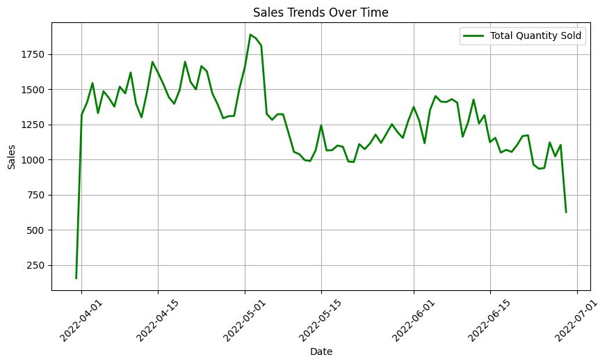

```python
# This graph shows the daily sales trends over time by Total quantity sold.
# We can identify the sales trends very easily by this visualization.
plt.figure(figsize=(10, 5))
sns.lineplot(
    data=daily_sales,
    x='Date',
    y='total_qty',
    label='Total Quantity Sold',
    color='green',      # <-- changed color
    linewidth=2
)
plt.title('Sales Trends Over Time')
plt.xlabel('Date')
plt.ylabel('Sales')
plt.xticks(rotation=45)
plt.legend()
plt.grid(True)
plt.show()
```

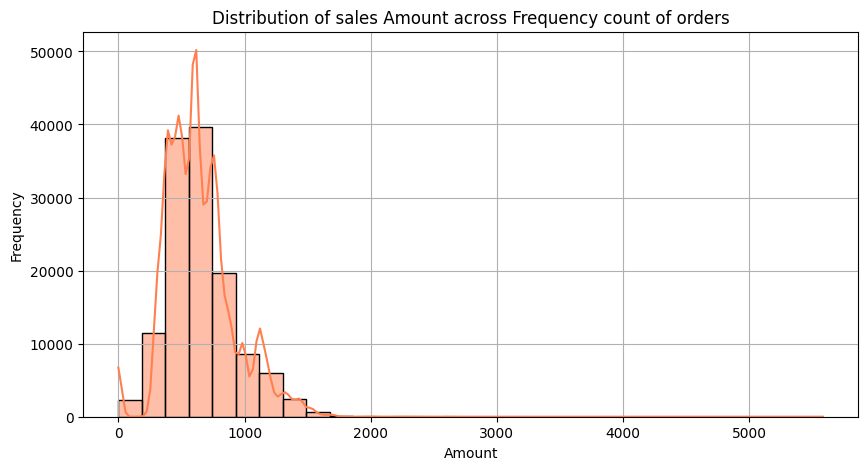

```python
plt.figure(figsize=(10, 5))
sns.histplot(df['Amount'], bins=30, kde=True, color='coral')
plt.title('Distribution of sales Amount across Frequency count of orders')
plt.xlabel('Amount')
plt.ylabel('Frequency')
plt.grid(True)
plt.show()
```

**Why we Handle outliers?:-** Extreme values that substantially differ from the rest of data are labeled as outliers. They can skew averages, exaggerate volatility, and mislead either models or analysis.

```python
Q1 = df['Amount'].quantile(0.25)
Q3 = df['Amount'].quantile(0.75)
IQR = Q3 - Q1
upper_bound = Q3 + 1.5 * IQR
lower_bound = Q1 - 1.5 * IQR
median_amount = df['Amount'].median()
df['Amount'] = df['Amount'].apply(
    lambda x: median_amount if x > upper_bound or x < lower_bound else x
)
df['Amount'] = df['Amount'].apply(
    lambda x: median_amount if x == 0 else x
)
```

**International Report:** International sales documents record transactions with customers, products, quantities, and sales amount. This set is good to analyze international sales, observe trends on monthly basis, assess how product perform, and juxtapose sale with domestic sale. One should use head(10) to view first 10 rows of the dataset and check column types, data quality and common entries

```python
international_df = pd.read_csv("/content/drive/MyDrive/Colab Notebooks/International sale Report.csv")
international_df
#international_df.head(10)
```

|  | index | DATE | Months | CUSTOMER | Style | SKU | Size | PCS | RATE | GROSS AMT |
| --- | --- | --- | --- | --- | --- | --- | --- | --- | --- | --- |
| 0 | 0 | 06-05-21 | Jun-21 | REVATHY LOGANATHAN | MEN5004 | MEN5004-KR-L | L | 1.00 | 616.56 | 617.00 |
| 1 | 1 | 06-05-21 | Jun-21 | REVATHY LOGANATHAN | MEN5004 | MEN5004-KR-XL | XL | 1.00 | 616.56 | 617.00 |
| 2 | 2 | 06-05-21 | Jun-21 | REVATHY LOGANATHAN | MEN5004 | MEN5004-KR-XXL | XXL | 1.00 | 616.56 | 617.00 |
| 3 | 3 | 06-05-21 | Jun-21 | REVATHY LOGANATHAN | MEN5009 | MEN5009-KR-L | L | 1.00 | 616.56 | 617.00 |
| 4 | 4 | 06-05-21 | Jun-21 | REVATHY LOGANATHAN | MEN5011 | MEN5011-KR-L | L | 1.00 | 616.56 | 617.00 |
| ... | ... | ... | ... | ... | ... | ... | ... | ... | ... | ... |
| 37427 | 37427 | AVIN | 03-31-22 | Mar-22 | PJNE3423 | PJNE3423-KR-4XL | 1.00 | 537.50 | 538.00 | 4.00 |
| 37428 | 37428 | AVIN | 03-31-22 | Mar-22 | PJNE3404 | PJNE3404-KR-4XL | 1.00 | 500.00 | 500.00 | 5.00 |
| 37429 | 37429 | AVIN | 03-31-22 | Mar-22 | PJNE3423 | PJNE3423-KR-4XL | 1.00 | 537.50 | 538.00 | 4.00 |
| 37430 | 37430 | AVIN | 03-31-22 | Mar-22 | SET290 | SET290-KR-DPT-M | 1.00 | 812.50 | 812.00 | 7.00 |
| 37431 | 37431 | AVIN | 03-31-22 | Mar-22 | SHIPPING | SHIPPING | 1.00 | 3666.00 | 3666.00 | 0.00 |

37432 rows × 10 columns

**Standardize columns and convert dates:-** Any sort of time based analysis has to make sure taht the dataset column is in datetime format, which is taken care of by this step. Then columns are renamed to be consistent with domestic sales dataset (PCS-QTY, GROSS AMT-Amount). Seasonal trend analysis and aggregation to larger time periods are allowed with the extraction of supplementary time-based variable such as Month, Year, and Day_of_week.

```python
# In the international sales datset, here we convert DATE column to datetime format
international_df['DATE'] = pd.to_datetime(international_df['DATE'], dayfirst=True, errors='coerce')
international_df.rename(columns={
    'PCS': 'Qty', # Number of items sold
    'GROSS AMT': 'Amount' # Total sales
}, inplace=True)
international_df['Month'] = international_df['DATE'].dt.month # It shows month number (1-12)
international_df['Year'] = international_df['DATE'].dt.year # It shows the year
international_df['Day_of_Week'] = international_df['DATE'].dt.day_name() # It shows the day name (monday, tuesday, wednesday,thursday,friday,saturday,sunday)
```

**Determine Sales Metrics:-** system of calculation for the key sales metrics are exercised to examine product and customer success:

1. Revenue_per_product determines the row-level revenue for each transaction.
2. By considering income per customer, Average_sales_per_order provides information on buying behavior at the individual-customer level.
3. Total quantity sold highlights products in high demand by adding quantities per SKU.
4. This measures help identify the major clients, the big-selling items, and overall sales performance.

```python
# It ensure the numerical columns are in correct type
international_df['Amount'] = pd.to_numeric(international_df['Amount'], errors='coerce')
international_df['Qty'] = pd.to_numeric(international_df['Qty'], errors='coerce')
international_df['Amount'] = international_df['Amount'].fillna(0) # Fill the missing values  or invalid numeric values by 0
international_df['Qty'] = international_df['Qty'].fillna(0)
international_df['Revenue_per_Product'] = international_df['Amount'] * international_df['Qty']
avg_sales = international_df.groupby('CUSTOMER')['Revenue_per_Product'].mean().reset_index() # Calculate revenue of per product
avg_sales.rename(columns={'Revenue_per_Product': 'Average_Sales_per_Order'}, inplace=True) # Calculate average sales
international_df = international_df.merge(avg_sales, on='CUSTOMER', how='left')
total_qty = international_df.groupby('SKU')['Qty'].sum().reset_index()
total_qty.rename(columns={'Qty': 'Total_Quantity_Sold'}, inplace=True)
international_df = international_df.merge(total_qty, on='SKU', how='left') # Merge them
```

**Product Classification:** Products are grouped for in-depth evaluation and contrast:

1. Style and SKU are combined in category_subcategory to produce a distinct product identifier.
2. Price_range_Bucket uses quantiles to classify object into low, medium, and high price ranges

```python
international_df['Category_Subcategory'] = international_df['Style'].astype(str) + " - " + international_df['SKU'].astype(str)
price_bins = international_df['Amount'].quantile([0, 0.33, 0.66, 1]).tolist()
international_df['Price_Range_Bucket'] = pd.cut(

    international_df['Amount'],
    bins=price_bins,
    labels=['Low', 'Medium', 'High'],
    include_lowest=True
)
```

```python
top5_products = international_df.groupby('Category_Subcategory')['Amount'].sum().to_frame()
top5_products = top5_products.sort_values(by='Amount', ascending=False).head(5)
monthly_sales = international_df.groupby(['Year', 'Month']).agg(
    total_qty=('Qty', 'sum'),
    total_amount=('Amount', 'sum')
).reset_index()
time_summary = international_df.groupby(['Year', 'Month', 'Day_of_Week']).agg(
    total_qty=('Qty', 'sum'),
    total_amount=('Amount', 'sum')
).reset_index()
```

**Business Question 3:-Which products are favored in abroad, and how do sales abroad change from month to month and day to day? How can these insights guide international inventory, marketing, and operational approches?**

**Solution:-**

1. Bar chart of the Top 5 Trending Products:- The bar chart showcases the five most popular products globally, generated by totaling all sales for each category subcategory. By utilizing this graphic to pinpoint high-demand products, the company can focus its marketing efforts, ensure sufficient inventory globally and emphasize logistics for top performing items.
2. Trends in international revenue are illustrated over time in the monthly line graph of overall sales (total figure). Sales peaks usually show up in months of higher demand, often connected to local holidays or special promotions. Knowing these patterns makes it much easier to plan marketing efforts, roll out global promotions, and manage stock so everything lines up with those busy sales periods.
3. Daily Quantity Sold (Line chart):- This line chart illustrate the total quantity sold each day in worldwide markets. This revelation of daily demand changes enables improved operational planning, staffing, and logistics management. Moreover, it helps in recognizing unsual demand surges or patterns taht may require further investigation or deliberate actions.

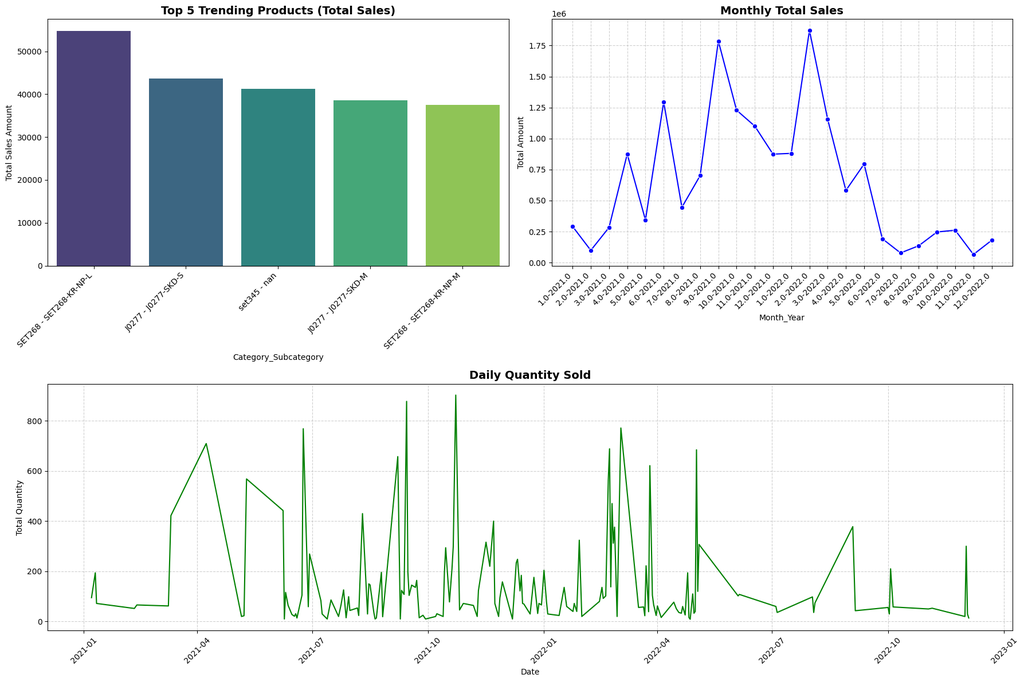

```python
top5_products = international_df.groupby('Category_Subcategory')['Amount'].sum().sort_values(ascending=False).head(5)
monthly_sales = international_df.groupby(['Year', 'Month']).agg(
    total_qty=('Qty', 'sum'),
    total_amount=('Amount', 'sum')
).reset_index()
monthly_sales['Month_Year'] = monthly_sales['Month'].astype(str) + '-' + monthly_sales['Year'].astype(str)

daily_sales = international_df.groupby('DATE').agg(
    total_qty=('Qty', 'sum'),
    total_amount=('Amount', 'sum')
).reset_index()


plt.figure(figsize=(18, 12))
plt.subplot(2, 2, 1)
sns.barplot(x=top5_products.index, y=top5_products.values, palette='viridis')
plt.title('Top 5 Trending Products (Total Sales)', fontsize=14, fontweight='bold')
plt.ylabel('Total Sales Amount')
plt.xticks(rotation=45, ha='right')

plt.subplot(2, 2, 2)
sns.lineplot(data=monthly_sales, x='Month_Year', y='total_amount', marker='o', color='blue')
plt.title('Monthly Total Sales', fontsize=14, fontweight='bold')
plt.ylabel('Total Amount')
plt.xticks(rotation=45, ha='right')
plt.grid(True, linestyle='--', alpha=0.6)

plt.subplot(2, 1, 2)
sns.lineplot(data=daily_sales, x='DATE', y='total_qty', color='green')
plt.title('Daily Quantity Sold', fontsize=14, fontweight='bold')
plt.ylabel('Total Quantity')
plt.xlabel('Date')
plt.xticks(rotation=45)
plt.grid(True, linestyle='--', alpha=0.6)
plt.tight_layout()
plt.show()
```

**Business question 4:-Which Nations, localities, and foreign consumers make up the largest portion of Amazon's revenue, and what effect does the ratio of domestic to foreign revenue have on company's overall business plan?**

**Solution:-**

```python
df['Revenue'] = pd.to_numeric(df['Amount'], errors='coerce') * pd.to_numeric(df['Qty'], errors='coerce')
df['Revenue'] = df['Revenue'].fillna(0)

international_df['Revenue'] = pd.to_numeric(international_df['Amount'], errors='coerce') * pd.to_numeric(international_df['Qty'], errors='coerce')
international_df['Revenue'] = international_df['Revenue'].fillna(0)
```

```python
total_domestic_revenue = df['Revenue'].sum()
total_international_revenue = international_df['Revenue'].sum()

print(f"Total Domestic Revenue: {total_domestic_revenue}")
print(f"Total International Revenue: {total_international_revenue}")
```

```
Total Domestic Revenue: 73954151.0
Total International Revenue: 464625351.77
```

```python
state_sales = df.groupby('ship-state')['Revenue'].sum().reset_index().sort_values(by='Revenue', ascending=False)
city_sales = df.groupby('ship-city')['Revenue'].sum().reset_index().sort_values(by='Revenue', ascending=False)
print(state_sales.head(5))
print(city_sales.head(5))
```

```
       ship-state     Revenue
28    MAHARASHTRA  12692563.0
23      KARNATAKA   9999908.0
57      TELANGANA   6491335.0
59  UTTAR PRADESH   6336364.0
56     TAMIL NADU   6184384.0
      ship-city    Revenue
776   BENGALURU  6589182.0
2906  HYDERABAD  4644195.0
4795     MUMBAI  3527872.0
5393  NEW DELHI  3425945.0
1466    CHENNAI  2947347.0
```

```python
!pip install squarify
```

```
Downloading squarify-0.4.4-py3-none-any.whl (4.1 kB)
```

[figure not shown]

```python
import squarify
country_sales = international_df.groupby('CUSTOMER')['Revenue'].sum().reset_index().sort_values(by='Revenue', ascending=False)
top10_customers = country_sales.head(10)

total_domestic_revenue = df['Revenue'].sum()
total_international_revenue = international_df['Revenue'].sum()
fig, axes = plt.subplots(1, 2, figsize=(18, 7))
squarify.plot(
    sizes=top10_customers['Revenue'],
    label=top10_customers['CUSTOMER'],
    value=top10_customers['Revenue'],
    color=plt.cm.Set3.colors,
    alpha=0.8,
    ax=axes[0]
)
axes[0].set_title("Top 10 International Customers by Revenue", fontsize=14, fontweight="bold")
axes[0].axis("off")
axes[1].pie(
    [total_domestic_revenue, total_international_revenue],
    labels=['Domestic', 'International'],
    autopct='%1.1f%%',
    startangle=140,
    colors=['#4C72B0', '#DD8452']
)
axes[1].set_title("Domestic vs International Revenue", fontsize=14, fontweight="bold")

plt.tight_layout()
plt.show()
```

**Business question 5:- How can identify these connections aid in developing more intelligent pricing schemes, product, and inventory plans that increase overall profits? Which sales and performance metrics typically move together?**

**Solution:-**

Pricing strategies may be influenced by the connection between sales volume or revenue and profit-related indicators (like profit_proxy and Profit_margin_proxy). While products with a high margin and average sales. may be highlighted to enhance profitability, items generating substantial revenue but with low profit margins might need cost adjustments.

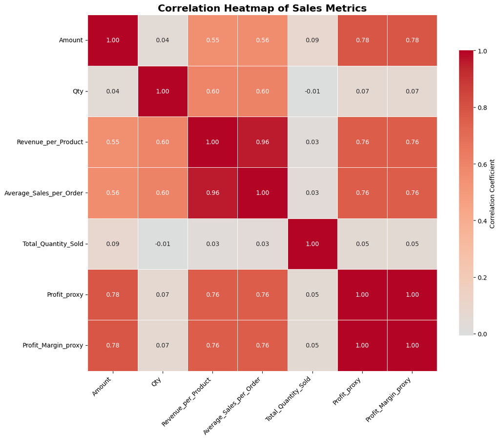

```python
numeric_cols = [
    'Amount',
    'Qty',
    'Revenue_per_Product',
    'Average_Sales_per_Order',
    'Total_Quantity_Sold',
    'Profit_proxy',
    'Profit_Margin_proxy'
]

corr_matrix = df[numeric_cols].corr()
# Plot  heatmap
plt.figure(figsize=(12, 10))
sns.heatmap(
    corr_matrix,
    annot=True,
    fmt=".2f",
    cmap='coolwarm',
    linewidths=0.5,
    center=0,
    cbar_kws={'shrink': 0.8, 'label': 'Correlation Coefficient'}
)
plt.title('Correlation Heatmap of Sales Metrics', fontsize=16, fontweight='bold')
plt.xticks(rotation=45, ha='right', fontsize=10)
plt.yticks(fontsize=10)
plt.tight_layout()
plt.show()
```

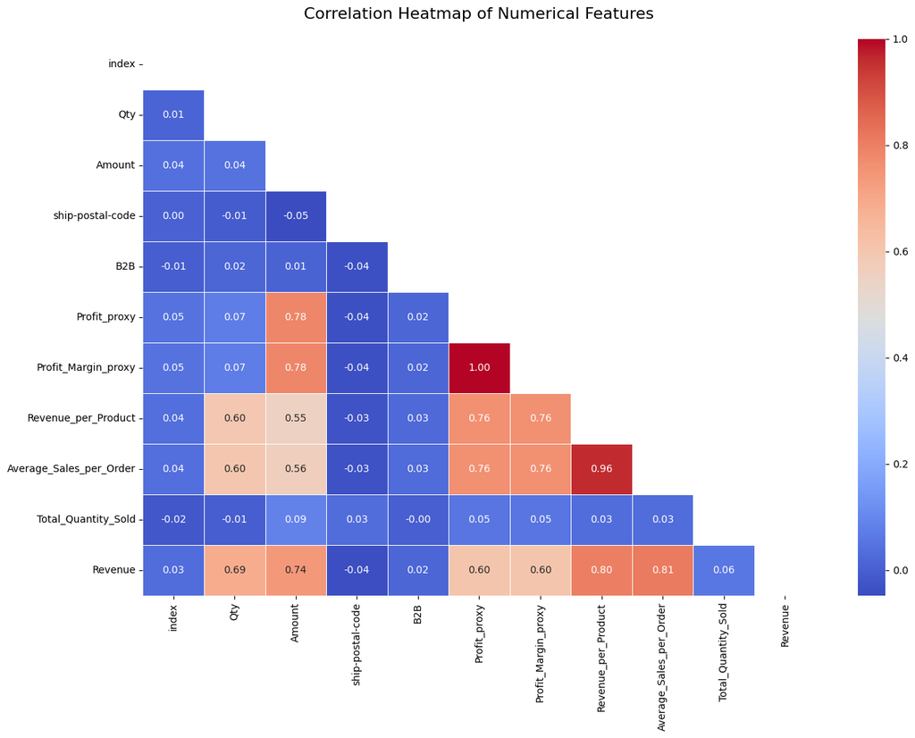

```python
plt.figure(figsize=(15,10))
corr_matrix = df.corr(numeric_only=True)
mask = np.triu(np.ones_like(corr_matrix, dtype=bool))
sns.heatmap(
    corr_matrix,
    annot=True,
    linewidths=0.5,
    cmap="coolwarm",
    mask=mask,
    fmt=".2f"
)
plt.title("Correlation Heatmap of Numerical Features", fontsize=16, pad=20)
plt.show()
```

**Business Question 6:- In which international markets do revenue and sales volume peak, and how can Amazon leverage this information to enhance its global operations, inventory control, and marketing tactis?**

```python
sales_summary = international_df.groupby('CUSTOMER').agg(total_pcs_sold=('Qty', 'sum'), total_revenue=('Amount', 'sum')).reset_index()
top_countries = sales_summary.sort_values(by='total_revenue', ascending=False)
```

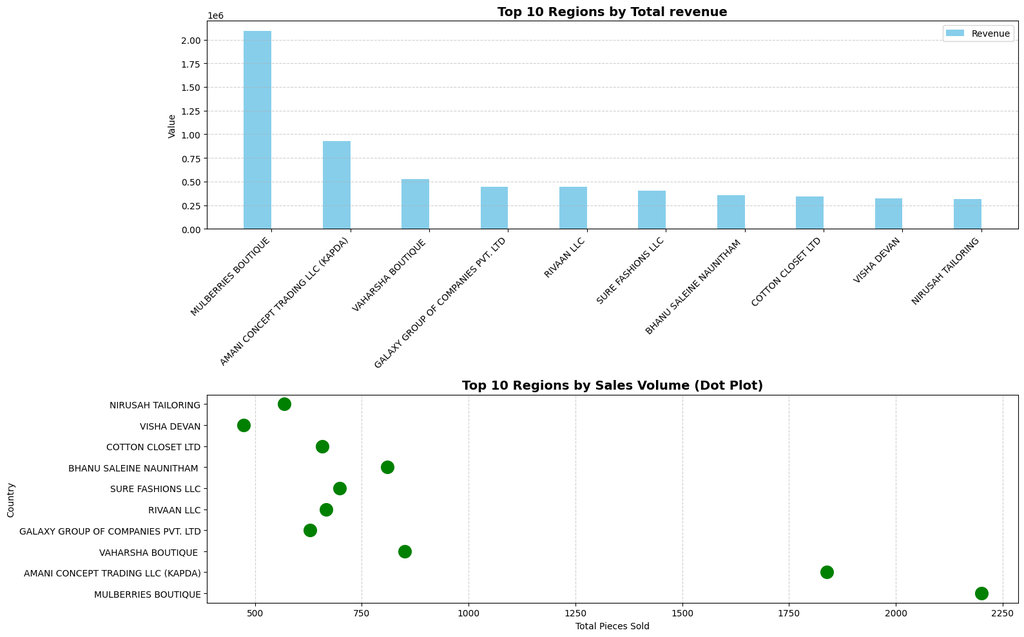

```python
top_10_customers = top_countries['CUSTOMER'][:10]
total_revenue = top_countries['total_revenue'][:10]
total_pcs_sold = top_countries['total_pcs_sold'][:10]
x = np.arange(len(top_10_customers))
width = 0.35
plt.figure(figsize=(16, 10))
plt.subplot(2, 1, 1)
plt.bar(x - width/2, total_revenue, width, label='Revenue', color='skyblue')

plt.xticks(x, top_10_customers, rotation=45, ha='right')
plt.ylabel('Value')
plt.title('Top 10 Regions by Total revenue', fontsize=14, fontweight='bold')
plt.legend()
plt.grid(axis='y', linestyle='--', alpha=0.6)

plt.subplot(2, 1, 2)
plt.scatter(total_pcs_sold, top_10_customers, s=200, color='green')
plt.xlabel('Total Pieces Sold')
plt.ylabel('Country')
plt.title('Top 10 Regions by Sales Volume (Dot Plot)', fontsize=14, fontweight='bold')
plt.grid(axis='x', linestyle='--', alpha=0.6)

plt.tight_layout()
plt.show()
```

**Conclusion:**

This project effectively converted raw Amazon sales data into organized, actionable insight by utilizing key data preprocessing methods like managing missing values, eliminating irrelevant columns, and structuring the dataset for analysis. As a result of this proces, the dataset was refined and more trustworthy, enabling precise analysis of customer behavior, roduct effectiveness, and revenue patterns in both domestic and global markets. Visual representations such as treemap, pie chart, bar chart, and dashboard emphasized key insights, including leading customers, revenue spread by region, and relationships among sales indicators.

Marketing strategic judgements is greatly aided by the knowledge acquired. Business can use these data to pinpoint thier most lucrative clients, enhance their sales tactis, and concentrate on industries or product categories with the greatest room of expansion.

**References**

1. Lee, Y. P., Wong, P., & Tan, C. H. (2025). A study of data-driven methods for inventory optimization. arXiv preprint arXiv:2505.08673.
2. Rekik, Y., Sahin, E., & Dallery, Y. (2025). Inventory record inaccuracy in grocery retailing: Impact of promotions and product perishability, and targeted effect of audits. arXiv preprint arXiv:2506.05357.
3. Kwak, J. K. (2019). Analysis of inventory turnover as a performance measure in manufacturing industry. Processes, 7(10), 760.
4. Babiloni, E., Guijarro, E., & Trapero, J. R. (2023). Stock control analytics: A data-driven approach to compute the fill rate considering undershoots. Optimization and Engineering, 25(2), 569–592.
5. Chong, A. Y. L., & Li, B. (2019). Business analytics and firm performance: role of structured financial statement data. Journal of Decision Systems, 28(3), 131–142.